Research case study

# A word can do the work of a hundred data points

When someone tells you "blickets make the machine go," you generalize further than when they say "this blicket makes the machine go" — even looking at identical evidence. Two studies, 1,371 participants ages 4 to 86, test how far instructional phrasing pulls people away from what they actually observed.

Zoe Finiasz, Ph.D. · Fresh reanalysis, 2026 · Original data: Finiasz, Gelman & Kushnir, *Cognition* (2024)

**My role:** I led the design and analysis of the developmental (child) study. For the adult study, I led the analysis and write-up, building on a design developed collaboratively with my co-authors. All analysis, modeling, and visualization on this page were rebuilt from scratch for this portfolio — independent of the published code and figures.

Try it

## Watch the gap between what's said and what's seen

Below is every adult participant's estimate, averaged by condition, across ten evidence levels — from an informant showing that just 1 in 10 items had a property, up to all 10. The dashed line is what a perfectly evidence-driven listener would say. Toggle a claim type on or off, and switch on the children's estimates to see the same pattern show up in 4-to-6-year-olds.

Overlay children's estimates (fixed at 30% evidence)

Hover the chart for exact estimates & sample sizes.

[interactive chart not shown]

Adults, N = 1,245 (label/property-endorsement trials excluded for missingness). Children, N = 121, ages 4–6. Fresh analysis of Finiasz, Gelman & Kushnir (2024) Study 1 & 2 data.

The instructional problem

## Curriculum and assessment language makes this choice constantly

Textbooks, science curricula, and test items routinely describe a category's properties in one of two grammatical forms — and the choice isn't neutral. Compare:

Generic claim "Sharks attack swimmers."

Specific / quantified claim "This shark attacked one swimmer." / "10% of sharks have attacked a swimmer."

The generic form implies the property is central and widespread — regardless of how rare it actually is. The specific and quantified forms tie the claim to a scope a learner can verify. If a learner then observes real, probabilistic evidence — a textbook figure, a lab result, a sample of cases — which phrasing they heard first changes how far they generalize beyond what they saw. That's the mechanism this project tests directly.

The design

## Two studies, one manipulation, two audiences

Both studies used the same core setup: participants heard one of four types of testimony about a novel category (a "blicket"), then watched a sample of objects pass through a machine, some proportion of which had a causal property. Afterward, they estimated how many *new* objects from the category would have the property.

1,249

Adults, MTurk

122

Children, ages 4–6

4

Testimony conditions

10%–100%

Evidence range (adults)

The one deliberate difference: adults saw evidence ranging from 10% to 100% prevalence, letting us trace a full dose-response curve. Children all saw a fixed, low evidence rate (30%) — the condition most likely to create real conflict between what they were told and what they saw, which is the sharpest test of whether testimony overrides observation.

What adults did

## Generic language flattens sensitivity to evidence

Adults' estimates tracked the evidence closely under Label Only and Specific phrasing — their estimates rose almost exactly in step with the true rate. Generic phrasing broke that relationship: it pulled estimates *up* when evidence was low and *down* when evidence was high, flattening the slope significantly (interaction b = −0.166, p = .001). "All" claims shifted every estimate upward by a roughly constant amount without changing how closely people tracked the evidence — a different mechanism producing a similar-looking overestimate.

What children did

## The same pull shows up before age six — more strongly

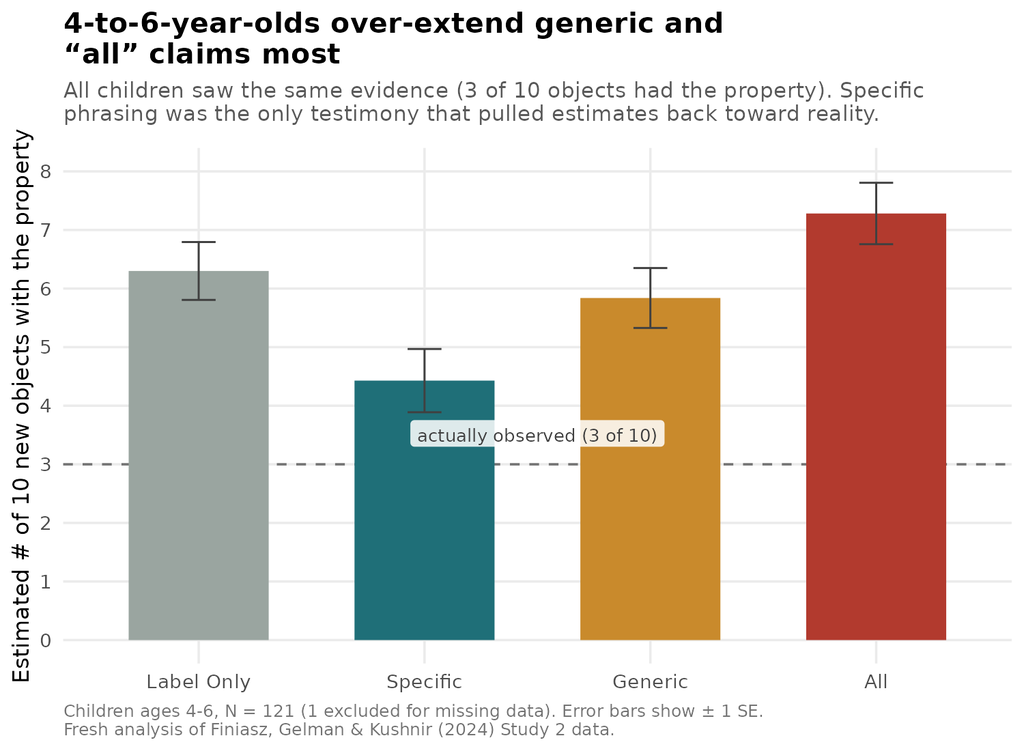

Fig. 1 — Children's prevalence estimates by condition. Fresh visualization; not reproduced from the published figures.

Does it hold across development?

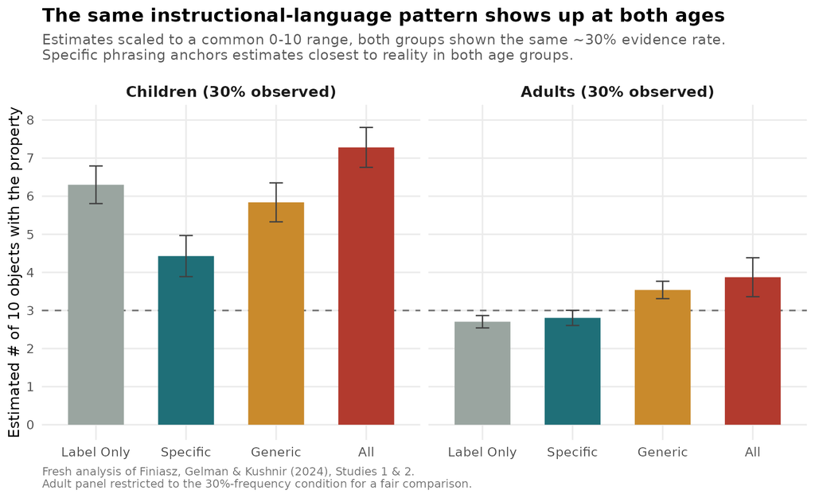

Fig. 2 — Developmental comparison at matched evidence (~30%). Built specifically for this case study; not part of the original published analysis.

Instructional implication

## Precision in phrasing is a design lever, not a style choice

If a curriculum or assessment item states a fact generically ("Mammals give live birth") rather than with an explicit scope or quantifier ("Most mammals give live birth" or "This mammal gives live birth"), learners — from age four through adulthood — will generalize further beyond the stated evidence than the material intends, and will be **less responsive to corrective evidence** presented afterward. For instructional designers, this argues for treating generic phrasing as a deliberate choice reserved for claims that are genuinely meant to generalize broadly — and for using specific or quantified language when the goal is precision, especially in materials aimed at younger learners, who show this effect most strongly.